# UCSB Department of Recreation

Instagram Analytics — Spring Quarter 2026

UCSB Rec Marketing

May 20, 2026

# 1 Executive Summary

Spring Quarter 2026 ran from **April 6 – May 18, 2026** (data through end of quarter export). UCSB Recreation published **33 posts** and **12 reels**, achieving an average engagement rate of **4%** on posts, up from 3.65% in Winter Quarter. No image-only posts were published this quarter; all content was either **carousel** (21 posts) or **video** (12 posts).

A new data source is available this quarter: **daily Profile Growth & Discovery** tracking, which captures follower counts, daily views, and daily reach, enabling trend analysis not possible with Winter data.

# 2 Profile Growth & Discovery

## 2.1 Follower Trend

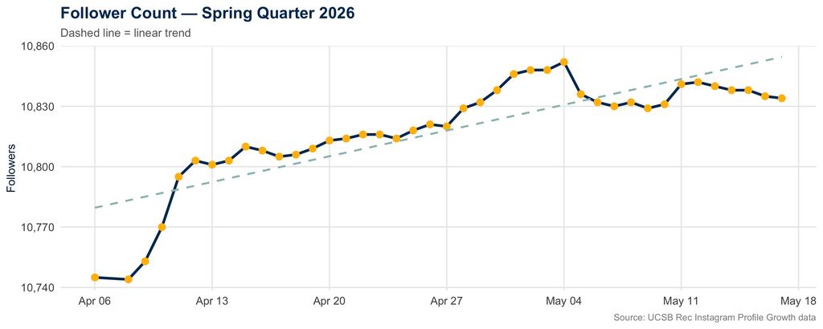

| Metric | Value |
| --- | --- |
| Followers at Start | 10,745 |
| Followers at End | 10,834 |
| Net Growth | +89 |
| Growth Rate | 0.83% |

## 2.2 Daily Views & Reach

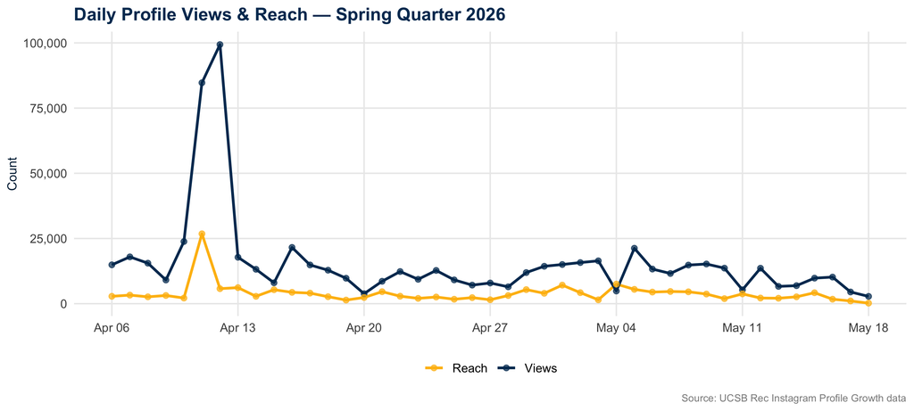

| Metric | Value |
| --- | --- |
| Total Profile Views | 668,675 |
| Total Reach | 168,760 |
| Avg Daily Views | 15,551 |
| Avg Daily Reach | 3,925 |
| Peak Views Day | 2026-04-12 |

# 3 Post Performance

## 3.1 Key Metrics

| Metric | Value |
| --- | --- |
| Total Posts | 33 |
| Avg Engagement Rate | 3.98% |
| Avg Reach | 4,907 |
| Avg Views | 12,489 |
| Total Likes | 6,689 |
| Total Saves | 147 |
| Total Shares | 693 |

## 3.2 Engagement Rate by Media Type

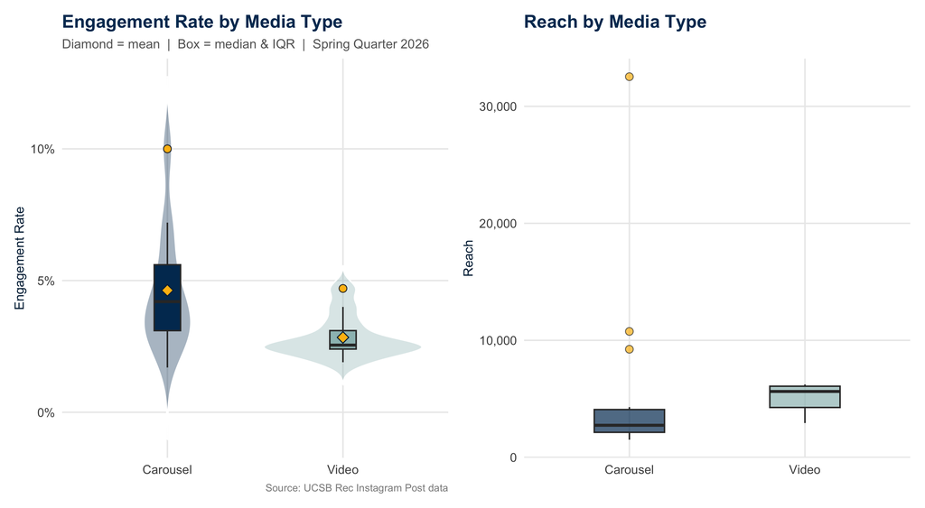

| Media_Type | # Posts | Avg Eng Rate | Avg Reach | Avg Views | Avg Likes | Avg Shares |
| --- | --- | --- | --- | --- | --- | --- |
| Carousel | 21 | 4.63% | 4,813 | 14,516 | 248 | 23 |
| Video | 12 | 2.84% | 5,073 | 8,941 | 124 | 18 |

## 3.3 Weekly Trends

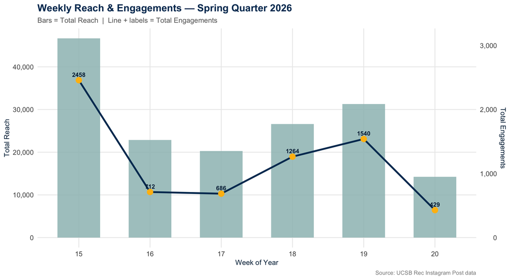

## 3.4 Best Day to Post

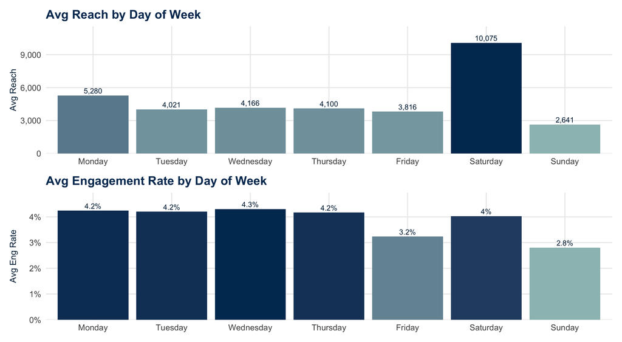

## 3.5 Top 10 Posts

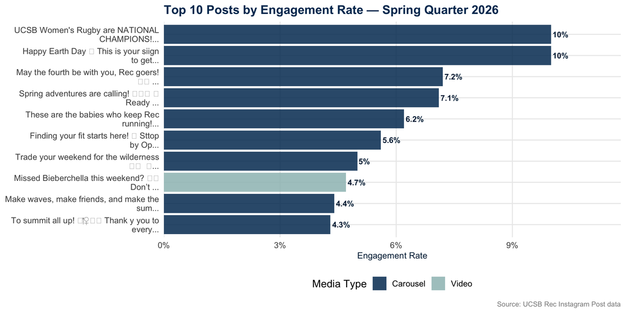

| Date | Caption | Type | Eng Rate | Reach | Likes | Saves | Shares |
| --- | --- | --- | --- | --- | --- | --- | --- |
| 2026-04-30 | UCSB Women’s Rugby are NATIONAL CHAMPIONS! 🏆🏉💙 The team is bringing home the tit | Carousel | 10% | 9236 | 859 | 9 | 46 |
| 2026-04-22 | Happy Earth Day 🌎 This is your sign to get outside this quarter!  We’re talkin | Carousel | 10% | 2904 | 280 | 4 | 8 |
| 2026-05-04 | May the fourth be with you, Rec goers! ⭐  Image Descriptions:  1. Anakin Skyw | Carousel | 7.2% | 10760 | 670 | 12 | 91 |
| 2026-04-07 | Spring adventures are calling! 🌄  Ready to get outside, unplug, and do somethi | Carousel | 7.1% | 4082 | 209 | 10 | 78 |
| 2026-05-08 | These are the babies who keep Rec running! 👶   Image Descriptions: 1. Baby pi | Carousel | 6.2% | 4291 | 240 | 4 | 7 |
| 2026-04-11 | Finding your fit starts here! 🤩 Stop by Open House today and learn more about ev | Carousel | 5.6% | 32535 | 1777 | 20 | 110 |
| 2026-05-05 | Trade your weekend for the wilderness 🌲  Join us May 22 - 25 for Sequoia Backp | Carousel | 5% | 2738 | 123 | 4 | 10 |
| 2026-04-13 | Missed Bieberchella this weekend? 😢 Don’t worry, REC-CHELLA is still going stron | Video | 4.7% | 6165 | 261 | 9 | 19 |
| 2026-05-13 | Make waves, make friends, and make the summer count! 🌊  From pool days and oce | Carousel | 4.4% | 2135 | 90 | NA | 4 |
| 2026-05-14 | To summit all up! 🧗‍♀️💥 Thank you to everyone who came out to this year’s Annual | Carousel | 4.3% | 3595 | 142 | 2 | 11 |